# Executive Summary

This report looks at the personal activity data collected from the accelerometers on the belt, forearm, arm and dumbell of 6 participants, and predicts how well the activity was performed. The participants were asked to perform barbell lifts correctly and incorrectly in 5 different ways. The data for this project come from this source: http://groupware.les.inf.puc-rio.br/har. Since this is a classification problem, we can use one of the following classification algorightms  
- Classification Trees - Bagging - Random Forests (Combination of Classification Trees and Bagging) - Boosting

We will use Random Forests as it gives the best accuracy. We want to have out of sample error rate of less than 5%

## Approach

The overall approach to predict the model can be summarized as

- Explore the data to get a basic understanding of the dataset
- Impute the data such that NAs are replaced with the means of the columns
- Get rid of all the predictors which have near zero variance
- Now check for correlation among the remaining predictors and remove collinearity

I used the principal component analysis also, to get better predictors, but didn’t find the model any better, and PCA made it hard to understand the variables once the model was built.

## Load the dataset

```r
setwd("/Users/msattarwala/coursera/ml")
suppressMessages(library(caret))
if (!file.exists("pml-training.csv")) {
  download.file("https://d396qusza40orc.cloudfront.net/predmachlearn/pml-training.csv",method="curl",
                destfile="pml-training.csv")
  }
if (!file.exists('pml-testing.csv')) {
  download.file("https://d396qusza40orc.cloudfront.net/predmachlearn/pml-testing.csv",method="curl",
                destfile="pml-testing.csv")
  }
```

## Exploratory Analysis of the Dataset

```r
set.seed(12354)
trainData <- read.csv("pml-training.csv")
inTrain <- createDataPartition(y=trainData$classe,p=0.7,list=FALSE)
training <- trainData[inTrain,]
testing <- trainData[-inTrain,]
testData <- read.csv("pml-testing.csv")
dim(training)
```

```
## [1] 13737   160
```

```r
summary(training)
```

```
##        X            user_name    raw_timestamp_part_1 raw_timestamp_part_2
##  Min.   :    2   adelmo  :2754   Min.   :1.32e+09     Min.   :   294
##  1st Qu.: 4898   carlitos:2161   1st Qu.:1.32e+09     1st Qu.:253844
##  Median : 9837   charles :2497   Median :1.32e+09     Median :498769
##  Mean   : 9818   eurico  :2134   Mean   :1.32e+09     Mean   :501674
##  3rd Qu.:14732   jeremy  :2395   3rd Qu.:1.32e+09     3rd Qu.:752309
##  Max.   :19621   pedro   :1796   Max.   :1.32e+09     Max.   :998750
##
##           cvtd_timestamp new_window    num_window    roll_belt
##  05/12/2011 11:24:1063   no :13430   Min.   :  1   Min.   :-28.9
##  30/11/2011 17:11:1046   yes:  307   1st Qu.:224   1st Qu.:  1.1
##  28/11/2011 14:14:1040               Median :425   Median :114.0
##  02/12/2011 14:57: 975               Mean   :432   Mean   : 64.6
##  02/12/2011 14:58: 969               3rd Qu.:644   3rd Qu.:123.0
##  05/12/2011 11:25: 968               Max.   :864   Max.   :162.0
##  (Other)         :7676
##    pitch_belt        yaw_belt      total_accel_belt kurtosis_roll_belt
##  Min.   :-55.80   Min.   :-180.0   Min.   : 1.0              :13430
##  1st Qu.:  1.71   1st Qu.: -88.3   1st Qu.: 3.0     #DIV/0!  :    9
##  Median :  5.27   Median : -12.2   Median :17.0     -1.908453:    2
##  Mean   :  0.19   Mean   : -10.6   Mean   :11.3     -0.016850:    1
##  3rd Qu.: 14.90   3rd Qu.:  14.3   3rd Qu.:18.0     -0.021024:    1
##  Max.   : 60.30   Max.   : 179.0   Max.   :29.0     -0.025513:    1
##                                                     (Other)  :  293
##  kurtosis_picth_belt kurtosis_yaw_belt skewness_roll_belt
##           :13430            :13430              :13430
##  #DIV/0!  :   27     #DIV/0!:  307     #DIV/0!  :    8
##  -0.150950:    3                       0.422463 :    2
##  -0.684748:    3                       -0.010002:    1
##  -2.060105:    3                       -0.014020:    1
##  11.094417:    3                       -0.015465:    1
##  (Other)  :  268                       (Other)  :  294
##  skewness_roll_belt.1 skewness_yaw_belt max_roll_belt   max_picth_belt
##           :13430             :13430     Min.   :-94     Min.   : 3
##  #DIV/0!  :   27      #DIV/0!:  307     1st Qu.:-88     1st Qu.: 5
##  0.000000 :    4                        Median : -5     Median :18
##  -6.324555:    3                        Mean   : -7     Mean   :13
##  -0.189082:    2                        3rd Qu.: 19     3rd Qu.:19
##  -0.733570:    2                        Max.   :180     Max.   :30
##  (Other)  :  269                        NA's   :13430   NA's   :13430
```

[output cut: 289 more lines]

```
##  Min.   :-8.090   Min.   :-498.0   Min.   :-632    Min.   :-410.0
##  1st Qu.:-0.180   1st Qu.:-178.0   1st Qu.:  59    1st Qu.:-181.0
##  Median : 0.080   Median : -56.0   Median : 201    Median : -38.0
##  Mean   : 0.138   Mean   : -61.2   Mean   : 165    Mean   : -54.7
##  3rd Qu.: 0.490   3rd Qu.:  77.0   3rd Qu.: 313    3rd Qu.:  26.0
##  Max.   : 4.100   Max.   : 477.0   Max.   : 591    Max.   : 291.0
##
##  magnet_forearm_x magnet_forearm_y magnet_forearm_z classe
##  Min.   :-1280    Min.   :-896     Min.   :-973     A:3906
##  1st Qu.: -617    1st Qu.:  15     1st Qu.: 197     B:2658
##  Median : -376    Median : 594     Median : 512     C:2396
##  Mean   : -312    Mean   : 384     Mean   : 396     D:2252
##  3rd Qu.:  -73    3rd Qu.: 737     3rd Qu.: 654     E:2525
##  Max.   :  672    Max.   :1480     Max.   :1090
##
```

From summary we can quickly observe that some of the predictors don’t have a lot of variance.

## Data Cleaning

From the exploratory analysis we saw that there are some variables that we know will not be useful in our prediction model. Let’s remove them from our set of predictors

```r
drops <- c("X","user_name","raw_timestamp_part_1","raw_timestamp_part_2","cvtd_timestamp","new_window","num_window")
training <- training[,!(names(training) %in% drops)]
testing <- testing[,!(names(training) %in% drops)]
testData <- testData[,!(names(training) %in% drops)]
trainingClasse <- training$classe
testingClasse <- testing$classe
training <- training[,-which(colnames(training)=="classe")]
testing <- testing[,-which(colnames(testing)=="classe")]
testData <- testData[,-which(colnames(testData)=="problem_id")]
```

Also there are lot of NAs which we will replace with the mean of that variable to make it easier to work with the data.

```r
x <- data.matrix(training)
training <- data.frame(x)

x <- data.matrix(testing)
testing <- data.frame(x)

x <- data.matrix(testData)
testData <- data.frame(x)

impute.mean <- function(x){
  m <- mean(x, na.rm = TRUE)
  x[is.na(x)] <- m
  x
  }

x <- apply(training, 2, impute.mean)
training <- data.frame(x)

x <- apply(testing,2,impute.mean)
testing <- data.frame(x)

x <- apply(testData,2,impute.mean)
testData <- data.frame(x)
```

In the summary we also observed that quite a few predictors don’t have a lot of variance. Let’s remove those predictors.

```r
nzv <- nearZeroVar(training,saveMetrics=TRUE)
nzv <- nzv[nzv$nzv==FALSE,]

training <- training[,rownames(nzv)]

testing <- testing[,rownames(nzv)]

testData <- testData[,rownames(nzv)]
```

Remove collinearity among the predictors

```r
x <- cor(training)
y <- findCorrelation(x, cutoff = .75)

training <- training[,-y]
testing <- testing[,-y]
testData <- testData[,-y]
```

## Model Building

We will build the model using random forest. We will also get the importance of the variables used to build the classification trees, so we can examine which variables are more important.

```r
modelFit <- train(trainingClasse ~ .,data=training, method="rf",importance=TRUE,prox=TRUE,trControl=trainControl("cv"))
```

## Cross-Validation of Model

In random forests, there is no need for cross-validation or a separate test set to get an unbiased estimate of the test set error. It is estimated internally, during the run, as follows:

Each tree is constructed using a different bootstrap sample from the original data. About one-third of the cases are left out of the bootstrap sample and not used in the construction of the kth tree.

Put each case left out in the construction of the kth tree down the kth tree to get a classification. In this way, a test set classification is obtained for each case in about one-third of the trees. At the end of the run, take j to be the class that got most of the votes every time case n was oob. The proportion of times that j is not equal to the true class of n averaged over all cases is the oob error estimate. This has proven to be unbiased in many tests.  
But we have still partitioned our training set in training and test set so that we can cross-validate that we have picked the correct predictors.

```r
modelFit$finalModel
```

```
##
## Call:
##  randomForest(x = x, y = y, mtry = param$mtry, importance = TRUE,      proximity = TRUE)
##                Type of random forest: classification
##                      Number of trees: 500
## No. of variables tried at each split: 2
##
##         OOB estimate of  error rate: 0.76%
## Confusion matrix:
##      A    B    C    D    E class.error
## A 3904    2    0    0    0    0.000512
## B   15 2635    8    0    0    0.008653
## C    0   17 2368   11    0    0.011686
## D    0    0   41 2210    1    0.018650
## E    0    1    1    7 2516    0.003564
```

```r
predictions <- predict(modelFit,testing)
confusions <- confusionMatrix(testingClasse, predictions)
print(confusions)
```

```
## Confusion Matrix and Statistics
##
##           Reference
## Prediction    A    B    C    D    E
##          A 1672    1    0    0    1
##          B    5 1134    0    0    0
##          C    0    3 1017    6    0
##          D    0    0   17  946    1
##          E    0    0    0    3 1079
##
## Overall Statistics
##
##                Accuracy : 0.994
##                  95% CI : (0.991, 0.996)
##     No Information Rate : 0.285
##     P-Value [Acc > NIR] : <2e-16
##
##                   Kappa : 0.992
##  Mcnemar's Test P-Value : NA
##
## Statistics by Class:
##
##                      Class: A Class: B Class: C Class: D Class: E
## Sensitivity             0.997    0.996    0.984    0.991    0.998
## Specificity             1.000    0.999    0.998    0.996    0.999
## Pos Pred Value          0.999    0.996    0.991    0.981    0.997
## Neg Pred Value          0.999    0.999    0.997    0.998    1.000
## Prevalence              0.285    0.193    0.176    0.162    0.184
## Detection Rate          0.284    0.193    0.173    0.161    0.183
## Detection Prevalence    0.284    0.194    0.174    0.164    0.184
## Balanced Accuracy       0.998    0.998    0.991    0.993    0.999
```

As can be seen the accuracy of the predictions is pretty high and the out of sample error is wihin our bounds i.e. less than 5%.

Let’s plot the error rate for each class

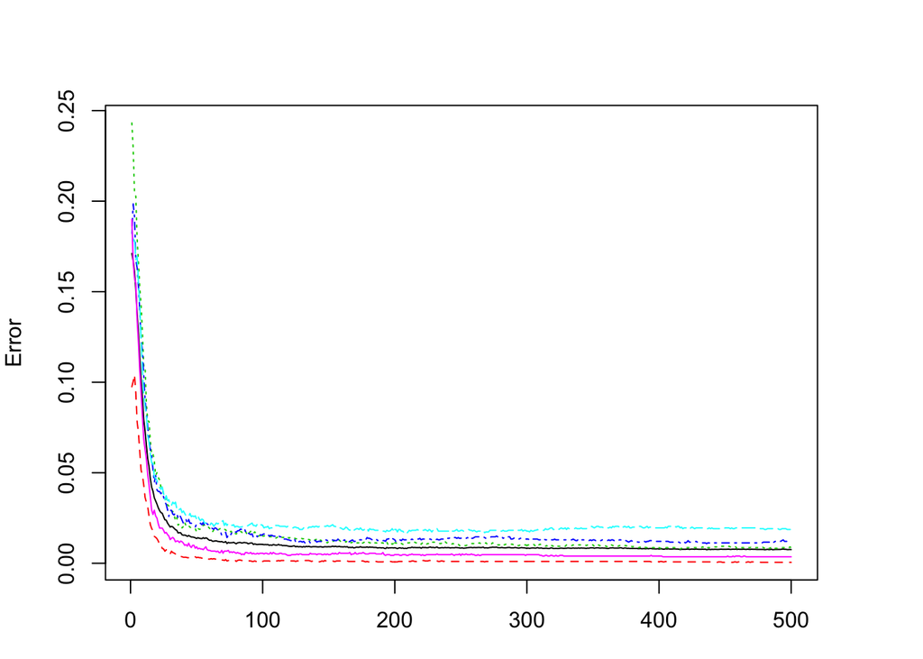

```r
par(mar=c(3,4,4,4))
plot(modelFit$finalModel,main="")
```

Let’s plot the importance of variables on Gini Index

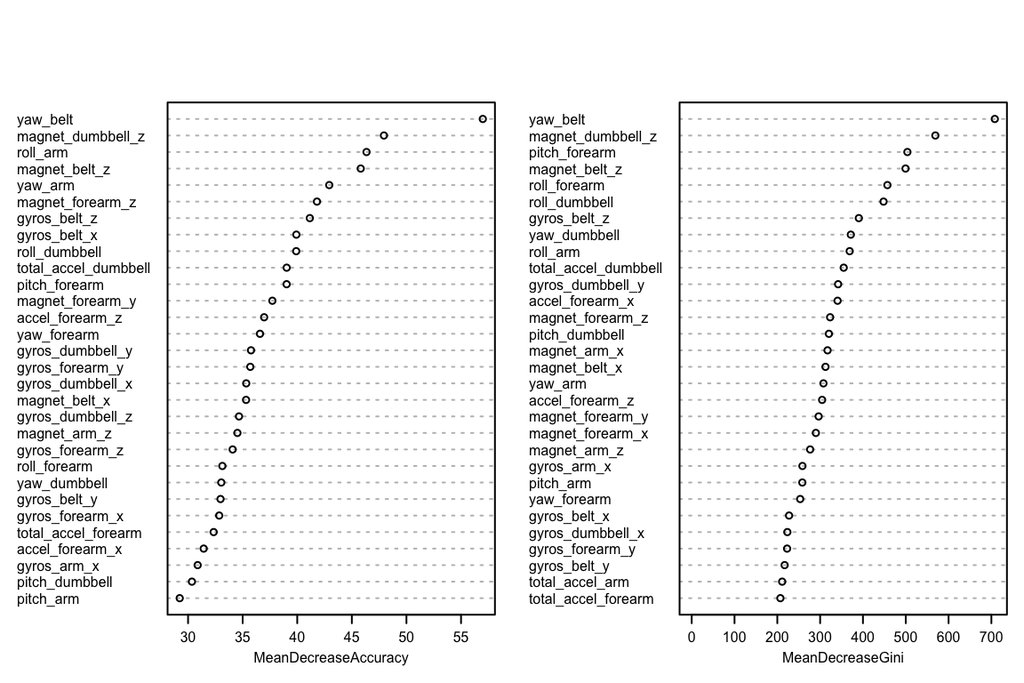

Predict the test set and generate answers

```r
testDataPredictions <- predict(modelFit,testData)
pml_write_files = function(x){
  n = length(x)
  for(i in 1:n){
    filename = paste0(getwd(),"/answers/problem_id_",i,".txt")
    write.table(x[i],file=filename,quote=FALSE,row.names=FALSE,col.names=FALSE)
    }
  }
pml_write_files(testDataPredictions)
```